# SPPH 504 Section 007 Lab (10.2) Mediation analysis on the CCHS analytic dataset

Ehsan Karim, ehsan.karim@ubc.ca

01 May 2020

Abstract

This is a short instruction document of how to perform mediation analysis on CCHS dataset.

# 1 Pre-processing

## 1.1 Load saved data

```r
load("OACVDmediate-part1.RData")
```

# 2 Mediation analysis

We want to decompose of the “total effect” of a given exposure OA ($A$) on the outcome CVD ($Y$) into

- a natural direct effect (NDE; $A \rightarrow Y$) and
- a natural indirect effect (NIE) through a mediator pain medication ($M$) through ($A \rightarrow M \rightarrow Y$).

## 2.1 Step 0: Build mediator model first

```r
# A = actual exposure (without any change)
analytic2$exposureTemp <- analytic2$exposure
w.design <- svydesign(id=~1, weights=~weight, data=analytic2)
# Replace exposure with exposureTemp
# This will be necessary in step 3
fit.m <- svyglm(mediator ~ exposureTemp +
                 age + sex + income + race + bmicat + edu +
                 smoke + fruit + ht + phyact + copd + diab,
                design = w.design,
                family = binomial("logit"))
publish(fit.m)
```

```
##      Variable             Units OddsRatio       CI.95     p-value
##  exposureTemp                        2.23 [1.85;2.70]     < 1e-04
##           age       20-39 years       Ref
##                     40-49 years      0.93 [0.83;1.04]   0.1824116
##                     50-59 years      0.65 [0.57;0.73]     < 1e-04
##                     60-64 years      0.59 [0.49;0.70]     < 1e-04
##           sex            Female       Ref
##                            Male      0.50 [0.46;0.55]     < 1e-04
##        income   $29,999 or less       Ref
##                 $30,000-$49,999      1.17 [1.01;1.36]   0.0383812
##                 $50,000-$79,999      1.22 [1.06;1.40]   0.0068936
##                 $80,000 or more      1.30 [1.12;1.50]   0.0004101
##          race         Non-white       Ref
##                           White      1.87 [1.65;2.13]     < 1e-04
##        bmicat            Normal       Ref
##                      Overweight      1.20 [1.09;1.32]   0.0002714
##                     Underweight      0.94 [0.74;1.19]   0.6149337
##           edu          < 2ndary       Ref
##                       2nd grad.      1.09 [0.92;1.29]   0.3057632
##                 Other 2nd grad.      1.27 [1.02;1.59]   0.0343119
##                  Post-2nd grad.      1.25 [1.08;1.46]   0.0035693
##         smoke    Current smoker       Ref
##                   Former smoker      0.99 [0.88;1.11]   0.8021965
##                    Never smoker      0.78 [0.69;0.89]   0.0001451
##         fruit 0-3 daily serving       Ref
##               4-6 daily serving      0.94 [0.84;1.05]   0.2784762
##                6+ daily serving      0.80 [0.70;0.91]   0.0009619
##            ht                No       Ref
##                             Yes      1.17 [1.01;1.36]   0.0352264
##        phyact            Active       Ref
##                        Inactive      1.08 [0.97;1.21]   0.1599760
##                        Moderate      1.08 [0.96;1.22]   0.1984575
##          copd                No       Ref
##                             Yes      2.10 [1.14;3.86]   0.0173972
##          diab                No       Ref
##                             Yes      1.26 [0.98;1.64]   0.0748179
```

## 2.2 Step 1 and 2: Replicate data with different exposures

```r
dim(analytic2)
```

```
## [1] 21623    23
```

```r
d1 <- d2 <- analytic2
# Create counterfactual data
# This will be necessary in step 3
# Exposed = Exposed
d1$exposure.counterfactual <- d1$exposure
# Exposed = Not exposed
d2$exposure.counterfactual <- !d2$exposure
# duplicated data (double the amount)
newd <- rbind(d1, d2)
newd <- newd[order(newd$id), ]
dim(newd)
```

```
## [1] 43246    24
```

## 2.3 Step 3: Compute weights for the mediation

Weight is computed by

$W^{M|C} = \frac{P(M|A^*, C)}{P(M|A, C)}$.

- $P(M|A, C)$ is computed from a logistic regression of $M$ on $A$ + $C$.
  - $logit [P(M=1 | C = c]) = \beta_0 + \beta_1 a + \beta_3 c$
- $P(M|A^{*}, C)$ is computed from a logistic regression of $M$ on $A^*$ + $C$.
  - $logit [P(M=1 | C = c]) = \beta_0 + \beta'_1 a^* + \beta'_3 c$

```r
# First, use original exposure (all A + all A):
# A = actual exposure (without any change)
# A = exposure
newd$exposureTemp <- newd$exposure
# Probability of M given A + C
w <- predict(fit.m, newdata=newd, type='response')
direct <- ifelse(newd$mediator, w, 1-w)
# Second, use counterfactual exposures (all A + all !A):
# A* = Opposite (counterfactual) values of the exposure
# A* = exposure.counterfactual
newd$exposureTemp <- newd$exposure.counterfactual
# Probability of M given A* + C
w <- predict(fit.m, newdata=newd, type='response')
indirect <- ifelse(newd$mediator, w, 1-w)
# Mediator weights
newd$W.mediator <- indirect/direct
summary(newd$W.mediator)
```

```
##    Min. 1st Qu.  Median    Mean 3rd Qu.    Max.
##  0.4789  1.0000  1.0000  1.0013  1.1321  2.0990
```

Incorporating the survey weights:

```r
# scale survey weights
newd$S.w <- with(newd,(weight)/mean(weight))
summary(newd$S.w)
```

```
##     Min.  1st Qu.   Median     Mean  3rd Qu.     Max.
##  0.02493  0.35176  0.65683  1.00000  1.25785 15.11619
```

```r
# Multiply mediator weights with scaled survey weights
newd$SM.w <- with(newd,(W.mediator * S.w))
summary(newd$SM.w)
```

```
##     Min.  1st Qu.   Median     Mean  3rd Qu.     Max.
##  0.01815  0.33877  0.63987  1.00004  1.23850 17.94296
```

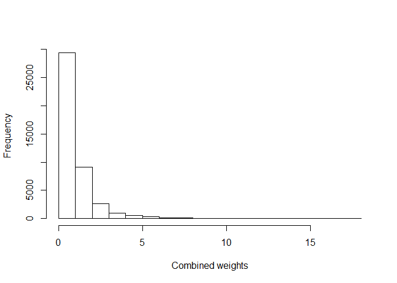

```r
hist(newd$SM.w, main = "", xlab = "Combined weights",
     ylab = "Frequency", freq = TRUE)
```

## 2.4 Step 4: Weighted outcome Model

Outcome model is

$logit [P(Y_{a,M(a^*)}=1 | C = c)] = \theta_0 + \theta_1 a + \theta_2 a^* + \theta_3 c$

after weighting (combination of mediator weight + sampling weight).

```r
# Outcome analysis
w.design <- svydesign(id=~id, weights=~SM.w,
                      data=newd)
# Fit Y on (A + A* + C)
fit <- svyglm(outcome ~ exposure + exposure.counterfactual +
               age + sex + income + race + bmicat + edu +
               smoke + fruit + ht + phyact + copd + diab,
             design = w.design,
               family = binomial("logit"))
```

### 2.4.1 Point estimates

Following are the conditional ORs:

- $OR_{TE}(C=c) = \exp(\theta_1 + \theta_2)$
- $OR_{NDE}(A=1,M=0,C=c) = \exp(\theta_1)$
- $OR_{NIE}(A^{*}=1,M=0,C=c) = \exp(\theta_2)$

```r
TE <- exp(sum(coef(fit)[c('exposure', 'exposure.counterfactual')]))
TE # total effect of A-> Y + A -> M -> Y
```

```
## [1] 1.476994
```

```r
DE <- exp(unname(coef(fit)['exposure']))
DE # direct effect of A-> Y (not through M)
```

```
## [1] 1.420437
```

```r
IE <- exp(unname(coef(fit)[c('exposure.counterfactual')]))
IE # indirect effect of A-> Y (A -> M -> Y)
```

```
## [1] 1.039817
```

```r
DE * IE # Product of ORs; same as TE
```

```
## [1] 1.476994
```

```r
PM <- log(IE) / log(TE)
PM # Proportion mediated
```

```
## [1] 0.1001116
```

### 2.4.2 Obtaining results fast

User-written funtion `doEffectDecomp()` (specific to OA-CVD problem):

```r
doEffectDecomp(analytic2, ind = NULL)
```

```
##        TE        DE        IE        PM
## 1.4769940 1.4204370 1.0398167 0.1001116
```

```r
# function is provided in the appendix
```

### 2.4.3 Confidence intervals

Standard errors and confidence intervals are determined by bootstrap methods.

```r
require(boot)
# I ran the computation on a 24 core computer,
# hence set ncpus = 20 (kept 4 free).
# If you have more / less cores, adjust accordingly.
# Try parallel package to find how many cores you have.
# library(parallel)
# detectCores()
# doEffectDecomp is a user-written function
# See appendix for the function
bootresBin <- boot(data=analytic2, statistic=doEffectDecomp,
                R = 10, parallel = "multicore", ncpus=20)
```

R = 10 is not reliable for bootstrap. In real applications, try 250.

```r
bootci1b <- boot.ci(bootresBin,type = "perc",index=1)
bootci2b <- boot.ci(bootresBin,type = "perc",index=2)
bootci3b <- boot.ci(bootresBin,type = "perc",index=3)
bootci4b <- boot.ci(bootresBin,type = "perc",index=4)
# Number of bootstraps
bootresBin$R
```

```
## [1] 10
```

```r
# Total Effect
c(bootresBin$t0[1], bootci1b$percent[4:5])
```

```
##       TE
## 1.476994 1.361512 2.099931
```

```r
# Direct Effect
c(bootresBin$t0[2], bootci2b$percent[4:5])
```

```
##       DE
## 1.420437 1.288368 2.096588
```

```r
# Indirect Effect
c(bootresBin$t0[3], bootci3b$percent[4:5])
```

```
##        IE
## 1.0398167 0.9999559 1.0567721
```

```r
# Proportion Mediated
c(bootresBin$t0[4], bootci4b$percent[4:5])
```

```
##            PM
##  1.001116e-01 -7.334843e-05  1.789366e-01
```

The proportion mediated through pain medication was about 10.01% on the log odds ratio scale.

### 2.4.4 Visualization for main effects

```r
require(plotrix)
TEc <- c(bootresBin$t0[1], bootci1b$percent[4:5])
DEc <- c(bootresBin$t0[2], bootci2b$percent[4:5])
IEc <- c(bootresBin$t0[3], bootci3b$percent[4:5])
mat<- rbind(TEc,DEc,IEc)
colnames(mat) <- c("Point", "2.5%", "97.5%")
mat
```

```
##        Point      2.5%    97.5%
## TEc 1.476994 1.3615116 2.099931
## DEc 1.420437 1.2883683 2.096588
## IEc 1.039817 0.9999559 1.056772
```

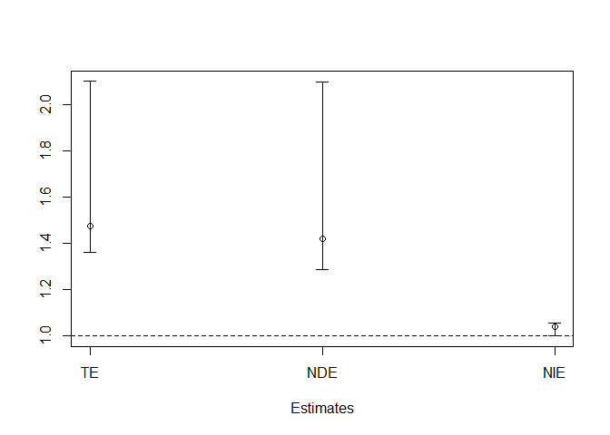

```r
plotCI(1:3, mat[,1], ui=mat[,3], li=mat[,2],
       xlab = "Estimates", ylab = "", xaxt="n")
axis(1, at=1:3,labels=c("TE","NDE","NIE"))
abline(h=1, lty = 2)
```

### 2.4.5 Non-linearity

Consider

- non-linear relationships (polynomials) and interactions between exposure, demographic/baseline covariates and mediators,
- Is misclassification of the mediators possible?

Here we are again using a user-written funtion `doEffectDecomp.int()` (including interactions `phyact*copd` and `phyact*diab` in the mediation model as well as the outcome model):

```r
# doEffectDecomp.int is a user-written function
# See appendix for the function
doEffectDecomp.int(analytic2, ind = NULL)
```

```
##        TE        DE        IE        PM
## 1.4694438 1.4112767 1.0412160 0.1049387
```

```r
# try bootstrap on it?
```

### 2.4.6 Visualization for main + interactions

```r
set.seed(127)
bootresInt <- boot(data=analytic2, statistic=doEffectDecomp.int,
                R = 10, parallel = "multicore", ncpus=20)
```

R = 10 is not reliable for bootstrap. In real applications, try 250.

```r
bootci1i <- boot.ci(bootresInt,type = "perc",index=1)
bootci2i <- boot.ci(bootresInt,type = "perc",index=2)
bootci3i <- boot.ci(bootresInt,type = "perc",index=3)
bootci4i <- boot.ci(bootresInt,type = "perc",index=4)
bootresInt$R
```

```
## [1] 10
```

```r
# from saved boostrap results: bootresInt
# (similar as before)
TEc <- c(bootresInt$t0[1], bootci1i$percent[4:5])
DEc <- c(bootresInt$t0[2], bootci2i$percent[4:5])
IEc <- c(bootresInt$t0[3], bootci3i$percent[4:5])
mat<- rbind(TEc,DEc,IEc)
colnames(mat) <- c("Point", "2.5%", "97.5%")
mat
```

```
##        Point     2.5%    97.5%
## TEc 1.469444 1.091575 1.666962
## DEc 1.411277 1.027937 1.579844
## IEc 1.041216 1.011060 1.086935
```

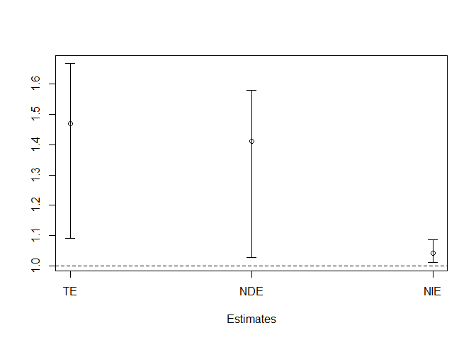

```r
plotCI(1:3, mat[,1], ui=mat[,3], li=mat[,2],
       xlab = "Estimates", ylab = "", xaxt="n")
axis(1, at=1:3,labels=c("TE","NDE","NIE"))
abline(h=1, lty = 2)
```

# 3 Appendix: OC-CVD Functions for bootstrap

These functions are written basically for performing bootstrap for the OA-CVD analysis. However, changing the covariates names/model-specifications should not be too hard, once you understand the basic steps.

```r
# without interactions (binary mediator)
doEffectDecomp
```

```
## function(dat, ind = NULL)
## {
##   #############################################
##   # This function is a modified version of
##   # Rochon, J., du Bois, A., & Lange, T. (2014).
##   # Mediation analysis of the relationship between
##   # institutional research activity and patient survival.
##   # BMC medical research methodology, 14(1), 9.
##   #############################################
##   # Comments at ehsan.karim@ubc.ca
##   #############################################
##   # Step 0: Replicate exposure variable, predict mediators
##   if (is.null(ind)) ind <- 1:nrow(dat)
##   d <- dat[ind,]
##   # d <- analytic2
##   d$exposureTemp <- d$exposure
##   w.design <- svydesign(id=~1, weights=~weight, data=d)
##   fit.m <- svyglm(mediator ~ exposureTemp  + age + sex +
##                    income + race + bmicat + phyact +
##                    smoke + fruit + ht +
##                    copd + diab + edu,
##                  design = w.design,
##                  family = quasibinomial("logit"))
##   # summary(fit.m)
##
##   # Steps 1 and 2: Replicate data with different exposures for mediator
##   d1 <- d2 <- d
##   d1$exposure.counterfactual <- d1$exposure
##   d2$exposure.counterfactual <- !d2$exposure
##   newd <- rbind(d1, d2)
##   newd <- newd[order(newd$id), ]
##
##   # Step 3: Compute weights for the mediation
##   newd$exposureTemp <- newd$exposure
##   w <- predict(fit.m, newdata=newd, type='response')
##   direct <- ifelse(newd$mediator, w, 1-w)
##   newd$exposureTemp <- newd$exposure.counterfactual
##   w <- predict(fit.m, newdata=newd, type='response')
##   indirect <- ifelse(newd$mediator, w, 1-w)
##   newd$W.mediator <- indirect/direct
```

[output cut: 10 more lines]

```
##                  age + sex + income + race + bmicat + edu +
##                  phyact + smoke + fruit + ht + copd + diab,
##                design = w.design,
##                family = quasibinomial("logit"))
##
##   # Return value: Estimates for total, direct, indirect effects
##   TE <- exp(sum(coef(fit)[c('exposure', 'exposure.counterfactual')]))
##   DE <- exp(unname(coef(fit)['exposure']))
##   IE <- exp(unname(coef(fit)[c('exposure.counterfactual')]))
##   PM <- log(IE) / log(TE)
##
##   return(c(TE=TE, DE=DE, IE=IE, PM=PM))
## }
## <bytecode: 0x0000000011aceed8>
## <environment: 0x00000000127afff8>
```

```r
# with interactions (binary mediator)
doEffectDecomp.int
```

```
## function(dat, ind = NULL)
## {
##   #############################################
##   # This function is a modified version of
##   # Rochon, J., du Bois, A., & Lange, T. (2014).
##   # Mediation analysis of the relationship between
##   # institutional research activity and patient survival.
##   # BMC medical research methodology, 14(1), 9.
##   #############################################
##   # Comments at ehsan.karim@ubc.ca
##   #############################################
##   # Step 0: Replicate exposure variable, predict mediators
##   if (is.null(ind)) ind <- 1:nrow(dat)
##   d <- dat[ind,]
##   # d <- analytic2
##   d$exposureTemp <- d$exposure
##   w.design <- svydesign(id=~1, weights=~weight, data=d)
##   fit.m <- svyglm(mediator ~ exposureTemp  + age + sex +
##                     income + race + bmicat + #phyact +
##                     smoke + fruit + ht +
##                     phyact*(copd + diab) + edu,
##                   design = w.design,
##                   family = quasibinomial("logit"))
##   # summary(fit.m)
##
##   # Steps 1 and 2: Replicate data with different exposures for mediator
##   d1 <- d2 <- d
##   d1$exposure.counterfactual <- d1$exposure
##   d2$exposure.counterfactual <- !d2$exposure
##   newd <- rbind(d1, d2)
##   newd <- newd[order(newd$id), ]
##
##   # Step 3: Compute weights for the mediation
##   newd$exposureTemp <- newd$exposure
##   w <- predict(fit.m, newdata=newd, type='response')
##   direct <- ifelse(newd$mediator, w, 1-w)
##   newd$exposureTemp <- newd$exposure.counterfactual
##   w <- predict(fit.m, newdata=newd, type='response')
##   indirect <- ifelse(newd$mediator, w, 1-w)
##   newd$W.mediator <- indirect/direct
```

[output cut: 10 more lines]

```
##                   age + sex + income + race + bmicat + edu +
##                   smoke + fruit + ht + phyact*(copd + diab),
##                 design = w.design,
##                 family = quasibinomial("logit"))
##
##   # Return value: Estimates for total, direct, indirect effects
##   TE <- exp(sum(coef(fit)[c('exposure', 'exposure.counterfactual')]))
##   DE <- exp(unname(coef(fit)['exposure']))
##   IE <- exp(unname(coef(fit)[c('exposure.counterfactual')]))
##   PM <- log(IE) / log(TE)
##
##   return(c(TE=TE, DE=DE, IE=IE, PM=PM))
## }
## <bytecode: 0x0000000011e90e08>
## <environment: 0x000000000e78c368>
```